Nadav Weisler, 316493758

Gaya Aran, 209636885

### Exercise 3

```r
require(ggplot2)
require(report)
require(effectsize)
require(dplyr)
require(emmeans)
```

# Part 1

## Question 1

```r
correlation_sim = function(N) {
  x1 = rnorm(n = N, mean = 100, sd = 15)
  x1 = as.numeric(x1)
  x2 = rnorm(n = N, mean = 100, sd = 50)
  x2 = as.numeric(x2)
  y = x1 + x2
  return(data.frame(x1 = x1, y = y))
}
```

## Question 2

Pearson’s r: 0.3668784 Degrees of freedom: 68 P-value: 0.001784

The Pearson’s product-moment correlation between samples$x1 and samples$y is positive, statistically significant, and large (r = 0.37, 95% CI [0.14, 0.55], t(68) = 3.25, p = 0.002)

```r
set.seed(1)
samples = correlation_sim(70)
cor.test(samples$x1, samples$y)
```

```
##
##  Pearson's product-moment correlation
##
## data:  samples$x1 and samples$y
## t = 3.2521, df = 68, p-value = 0.001784
## alternative hypothesis: true correlation is not equal to 0
## 95 percent confidence interval:
##  0.1443481 0.5540863
## sample estimates:
##       cor
## 0.3668784
```

```r
report(cor.test(samples$x1, samples$y))
```

```
## Effect sizes were labelled following Funder's (2019) recommendations.
##
## The Pearson's product-moment correlation between samples$x1 and samples$y is
## positive, statistically significant, and large (r = 0.37, 95% CI [0.14, 0.55],
## t(68) = 3.25, p = 0.002)
```

## Question 3

```r
quantiles = quantile(samples$x1, probs = c(0.25,0.50,0.75,1))

get_rate = function(val) {
  if (val[1] < quantiles[1]) {
    return("a")
  } else if (val[1] < quantiles[2]) {
    return ("b")
  } else if (val[1] < quantiles[3]) {
    return("c")
  } else {
    return ("d")
  }
}

samples$rate <- apply(samples, 1, get_rate)
```

## Question 4

F value: 2.06 Degrees of freedom: 3, 66 P-value: 0.114

The main effect of samples$rate is statistically not significant and medium (F(3, 66) = 2.06, p = 0.114; Eta2 = 0.09, 95% CI [0.00, 1.00])

```r
anova_test = aov(samples$y ~ samples$rate)
summary(anova_test)
```

```
##              Df Sum Sq Mean Sq F value Pr(>F)
## samples$rate  3  10484    3495    2.06  0.114
## Residuals    66 111937    1696
```

## Question 5

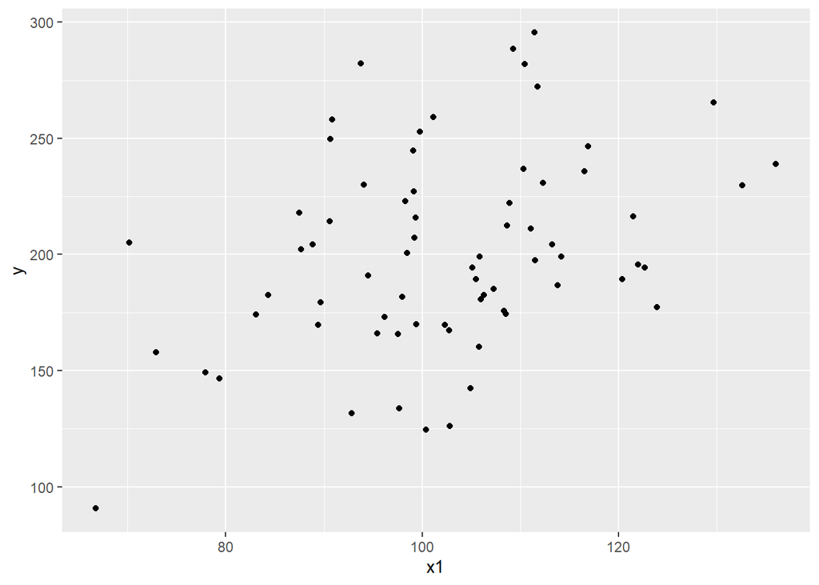

```r
ggplot(samples, aes(x=x1, y=y)) + geom_point()
```

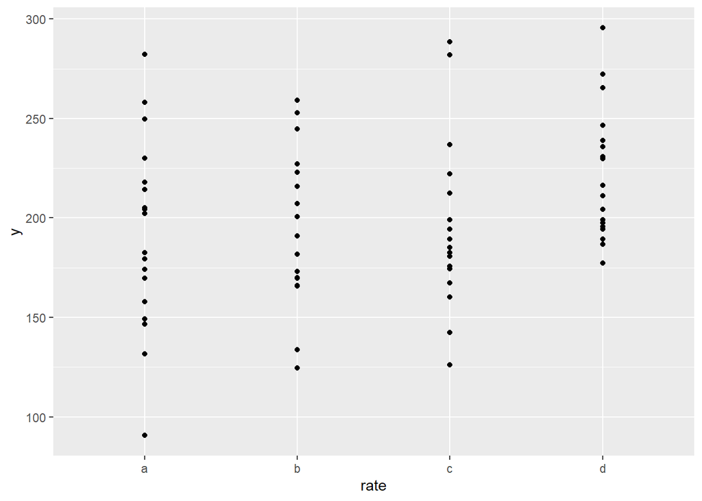

```r
ggplot(samples, aes(x=rate, y=y)) + geom_point()
```

## Question 6

Splitting the data into groups eliminated the significance of the results that was found while using the continuous measure. The graph that is divided into groups shows us that the fourth group is the one that probably directed the upward trend (or the positive correlation) the most (unlike the second and the third groups), and that a small number of observations might have influenced the reflected trend - for example, the lowest observation in the first group. In Other words, it helps to understand where the effect is coming from.

## Question 7

We don’t think this answer will always apply. Splitting into groups might show that the results from the correlation test were affected by outliers, but it could also confuse and miss the point of continuous measurement for connection. It causes our attention to deviate, we pay less attention to the actual relationship between variable X and Y, and it will be difficult to really perceive this with a superficial view - as we are doing now. In order to truly examine this question, it is necessary to create simulations that will examine how different situations are affected differently by splitting while changing each of the statistics and measuring the power.

## Question 8

The correlation decrease this makes sense because x1 is part of y, therefore any change in x1 change y to the same direction and because of that the correlation wont exist between x1 and x2.

```r
correlation_sim = function(N) {
  x1 = rnorm(n = N, mean = 100, sd = 15)
  x1 = as.numeric(x1)
  x2 = rnorm(n = N, mean = 100, sd = 50)
  x2 = as.numeric(x2)
  return(data.frame(x1 = x1, x2 = x2))
}
samples = correlation_sim(70)
cor.test(samples$x1, samples$x2)
```

```
##
##  Pearson's product-moment correlation
##
## data:  samples$x1 and samples$x2
## t = -0.16847, df = 68, p-value = 0.8667
## alternative hypothesis: true correlation is not equal to 0
## 95 percent confidence interval:
##  -0.2541793  0.2155835
## sample estimates:
##         cor
## -0.02042521
```

## Question 9

```r
p_vals = c(cor.test(samples$x1, samples$x2, alternative="greater")$p.value)

x1_sd = sd(samples$x1)
x1_mean = mean(samples$x1)
x2_sd = sd(samples$x2)
x2_mean = sd(samples$x2)
```

```r
samples_b = samples[(samples$x1 < (x1_mean + (1.5 * x1_sd))) &
                      (samples$x1 > (x1_mean - (1.5 * x1_sd))),]

p_vals = c(p_vals,
           cor.test(samples_b$x1, samples_b$x2, alternative="greater")$p.value)
```

```r
samples_c = samples[(samples$x2 < (x2_mean + (1.5 * x2_sd))) &
                      (samples$x2 > (x2_mean - (1.5 * x2_sd))),]

p_vals = c(p_vals,
           cor.test(samples_c$x1, samples_c$x2, alternative="greater")$p.value)
```

```r
samples_d = samples[(samples$x1 < (x1_mean + (2.5 * x1_sd))) &
                      (samples$x1 > (x1_mean - (2.5 * x1_sd))),]

p_vals = c(p_vals,
           cor.test(samples_d$x1, samples_d$x2, alternative="greater")$p.value)
```

```r
samples_e = samples[(samples$x2 < (x2_mean + (2.5 * x2_sd))) &
                      (samples$x2 > (x2_mean - (2.5 * x2_sd))),]

p_vals = c(p_vals,
           cor.test(samples_e$x1, samples_e$x2, alternative="greater")$p.value)
```

```r
samples_f = samples[(samples$x1 < max(samples$x1)) &
                      (samples$x1 > min(samples$x1)),]

p_vals = c(p_vals,
           cor.test(samples_f$x1, samples_f$x2, alternative="greater")$p.value)
```

## Question 10

The lowest value is the condition about outlier pairs which are more than 2.5 SDs from the mean of x2. We cant choose this after analysis because this decision was based on lowest p-value, and without scientific explanation which can increase the probability for type I error.

```r
print(p_vals)
```

```
## [1] 0.5666415 0.8061637 0.5411168 0.5666415 0.3220347 0.6715680
```

## Question 11

The chance of type I error in this simulation is 12.8%. this is the amount of significant p value in this simulation. the probability increase because we p-hacked in the analysis as we mentioned in the previous question.

```r
all_pvals = c()
for (i in 1:2000) {
  lowest_p_val = 1
  current_samples = correlation_sim(70)
  currnet_p_vals = c(cor.test(current_samples$x1,
                              current_samples$x2,
                              alternative="greater")$p.value)

  x1_sd = sd(current_samples$x1)
  x1_mean = mean(current_samples$x1)
  x2_sd = sd(current_samples$x2)
  x2_mean = sd(current_samples$x2)

  current_samples_b = current_samples[
    (current_samples$x1 < (x1_mean + (1.5 * x1_sd))) &
    (current_samples$x1 > (x1_mean - (1.5 * x1_sd))),]

  current_p_val = cor.test(current_samples_b$x1,
                           current_samples_b$x2,
                           alternative="greater")$p.value

  if (current_p_val < lowest_p_val) {
    lowest_p_val = current_p_val
  }

  current_samples_c = current_samples[
    (current_samples$x2 < (x2_mean + (1.5 * x2_sd))) &
    (current_samples$x2 > (x2_mean - (1.5 * x2_sd))),]

  current_p_val = cor.test(current_samples_c$x1,
                          current_samples_c$x2,
                          alternative="greater")$p.value

  if (current_p_val < lowest_p_val) {
    lowest_p_val = current_p_val
  }

  current_samples_d = current_samples[
    (current_samples$x1 < (x1_mean + (2.5 * x1_sd))) &
    (current_samples$x1 > (x1_mean - (2.5 * x1_sd))),]

  current_p_val = cor.test(current_samples_d$x1,
                           current_samples_d$x2,
                           alternative="greater")$p.value

  if (current_p_val < lowest_p_val) {
    lowest_p_val = current_p_val
  }

  current_samples_e = current_samples[
    (current_samples$x2 < (x2_mean + (2.5 * x2_sd))) &
    (current_samples$x2 > (x2_mean - (2.5 * x2_sd))),]

  current_p_val = cor.test(current_samples_e$x1,
                           current_samples_e$x2,
                           alternative="greater")$p.value

  if (current_p_val < lowest_p_val) {
    lowest_p_val = current_p_val
  }

  current_samples_f = current_samples[
    (current_samples$x1 < max(current_samples$x1)) &
    (current_samples$x1 > min(current_samples$x1)),]

  current_p_val = cor.test(current_samples_f$x1,
                           current_samples_f$x2,
                           alternative="greater")$p.value

  if (current_p_val < lowest_p_val) {
    lowest_p_val = current_p_val
  }

  all_pvals = c(all_pvals, lowest_p_val)
}
```

```r
sig_count = 0
for (p in all_pvals) {
  if (p < 0.05) {
    sig_count = sig_count + 1
  }
}
sig_count / 2000
```

```
## [1] 0.128
```

# Part 2

## Question 1

```r
OverallRecognition <- read.csv("Expt1_OverallRecognition.csv")
```

## Question 2

```r
anova_test_2 = aov(
  OverallRecognition$value ~
    OverallRecognition$valence *
    OverallRecognition$delay_cond)
summary(anova_test_2)
```

```
##                                                           Df Sum Sq Mean Sq
## OverallRecognition$valence                                 1  1.057  1.0565
## OverallRecognition$delay_cond                              1  0.232  0.2319
## OverallRecognition$valence:OverallRecognition$delay_cond   1  0.038  0.0375
## Residuals                                                488 23.055  0.0472
##                                                          F value   Pr(>F)
## OverallRecognition$valence                                22.363 2.96e-06 ***
## OverallRecognition$delay_cond                              4.909   0.0272 *
## OverallRecognition$valence:OverallRecognition$delay_cond   0.795   0.3732
## Residuals
## ---
## Signif. codes:  0 '***' 0.001 '**' 0.01 '*' 0.05 '.' 0.1 ' ' 1
```

```r
eta_squared(anova_test_2, partial=TRUE)
```

```
## # Effect Size for ANOVA (Type I)
##
## Parameter                                                | Eta2 (partial) |       95% CI
## ----------------------------------------------------------------------------------------
## OverallRecognition$valence                               |           0.04 | [0.02, 1.00]
## OverallRecognition$delay_cond                            |       9.96e-03 | [0.00, 1.00]
## OverallRecognition$valence:OverallRecognition$delay_cond |       1.63e-03 | [0.00, 1.00]
##
## - One-sided CIs: upper bound fixed at [1.00].
```

## Question 4

```r
emm = emmeans(anova_test_2, specs = ~ delay_cond * valence)
emm
```

```
##  delay_cond valence emmean     SE  df lower.CL upper.CL
##  Sleep      neg      0.762 0.0195 488    0.724    0.800
##  Wake       neg      0.701 0.0197 488    0.662    0.740
##  Sleep      neu      0.652 0.0195 488    0.614    0.690
##  Wake       neu      0.626 0.0197 488    0.587    0.665
##
## Confidence level used: 0.95
```

```r
all = c(0.5,-0.5,0.5, -0.5)
negative = c(1, -1, 0, 0)
neutral = c(0, 0, 1, -1)
contrast(emm, method = list("All" = all,
                            "Negative" = negative,
                            "Neutral" = neutral))
```

```
##  contrast estimate     SE  df t.ratio p.value
##  All        0.0434 0.0196 488   2.216  0.0272
##  Negative   0.0609 0.0277 488   2.197  0.0285
##  Neutral    0.0260 0.0277 488   0.936  0.3495
```

## Question 5

```r
pairs(emm, adjust="tukey", simple = c("delay_cond", "valence"))
```

```
##  contrast              estimate     SE  df t.ratio p.value
##  Sleep neg - Wake neg    0.0609 0.0277 488   2.197  0.1255
##  Sleep neg - Sleep neu   0.1100 0.0276 488   3.985  0.0005
##  Sleep neg - Wake neu    0.1360 0.0277 488   4.905  <.0001
##  Wake neg - Sleep neu    0.0491 0.0277 488   1.772  0.2881
##  Wake neg - Wake neu     0.0751 0.0278 488   2.697  0.0363
##  Sleep neu - Wake neu    0.0260 0.0277 488   0.936  0.7853
##
## P value adjustment: tukey method for comparing a family of 4 estimates
```

```r
emm_2 = emmeans(anova_test_2, specs = ~ delay_cond)
```

```
## NOTE: Results may be misleading due to involvement in interactions
```

```r
pairs(emm_2,adjust="tukey")
```

```
##  contrast     estimate     SE  df t.ratio p.value
##  Sleep - Wake   0.0434 0.0196 488   2.216  0.0272
##
## Results are averaged over the levels of: valence
```

```r
emm_3 = emmeans(anova_test_2, specs = ~ valence)
```

```
## NOTE: Results may be misleading due to involvement in interactions
```

```r
pairs(emm_3, adjust="tukey")
```

```
##  contrast  estimate     SE  df t.ratio p.value
##  neg - neu   0.0925 0.0196 488   4.722  <.0001
##
## Results are averaged over the levels of: delay_cond
```

## Question 6

There is no difference between the results since there are only two levels and therefore one comparison for each level which is identical to the method in the contrast analysis. As a result the p-value stay the same.

## Question 7

```r
summarise_results <- summarise(group_by(OverallRecognition, delay_cond, valence),
                         sd=sd(value),
                         mean=mean(value))
```

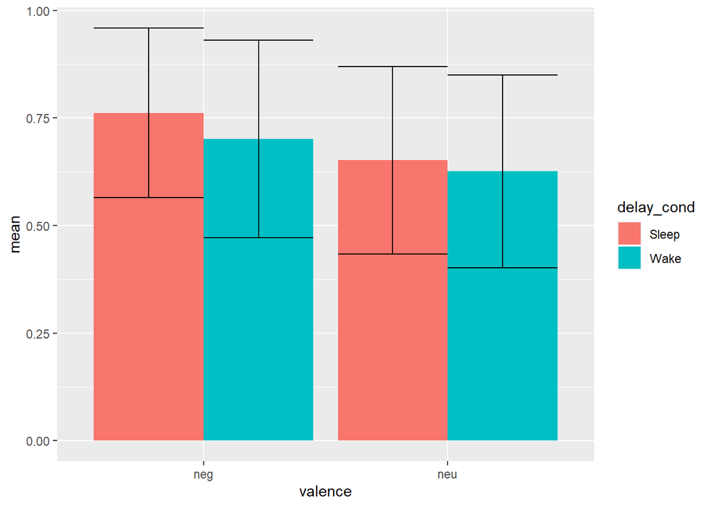

```r
ggplot(summarise_results, aes(x = valence,
                              y = mean,
                              fill = delay_cond)) +
  geom_bar(stat = "identity", position = "dodge") +
geom_errorbar(aes(ymin=mean-sd, ymax=mean+sd),
              position = position_dodge(0.9))
```

## Question 8

We can see there is a significant main effects between the two valences and significant (but smaller then the valence effect) effect in the delay condition but without any interaction effect.